# Pronosticar Importaciones de Autos

Importaciones en EEUU de autos mexicanos

Published

September 9, 2026

### Carga de Data

```r
library(tidyverse)
library(fpp3)
import <- tidyquant :: tq_get(
    x = "Mauinsa",
    get = "economic.data",
    from = "1993-01-01",
    to = "2025-10-01"
) |>
    mutate(
        date = yearmonth(date)
    ) |>
    as_tsibble(index = date)
```

### Modelo STL de referencia

Este modelo lo hago para tener una referencia clara de la estacionalidad y tendencia

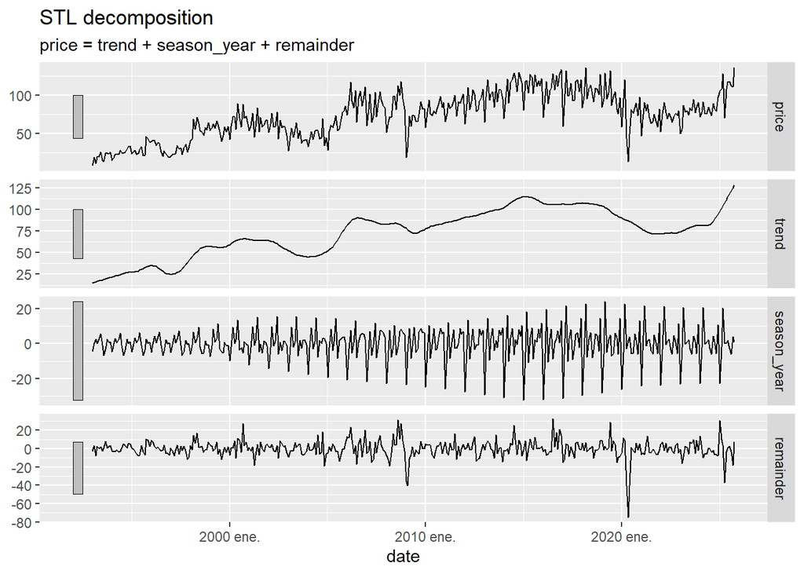

```r
import |>
    model(
        stl = STL(price, robust = TRUE)
    ) |>
    components() |>
    autoplot()
```

### Pronostico

```r
h <- 14

train <- import |>
  slice_head(n = nrow(import) - h)

test <- import |>
  slice_tail(n = h)
```

```r
fit_train <- train |>
  model(
    Media = MEAN(price),
    Naive = NAIVE(price),
    Snaive = SNAIVE(price),
    Deriva = RW(price ~ drift())
  )

fc_train <- fit_train |>
  forecast(h = h)

accuracy(fc_train, import) |>
  arrange(RMSE)
```

```
# A tibble: 4 × 10
  .model .type    ME  RMSE   MAE   MPE  MAPE  MASE RMSSE  ACF1
  <chr>  <chr> <dbl> <dbl> <dbl> <dbl> <dbl> <dbl> <dbl> <dbl>
1 Snaive Test   22.5  29.8  24.9  18.9  21.9  1.88  1.65 0.172
2 Deriva Test   29.5  34.4  30.2  25.8  26.8  2.27  1.90 0.143
3 Naive  Test   30.8  35.8  31.3  27.0  27.7  2.36  1.98 0.173
4 Media  Test   32.8  37.5  33.0  29.0  29.3  2.49  2.07 0.173
```

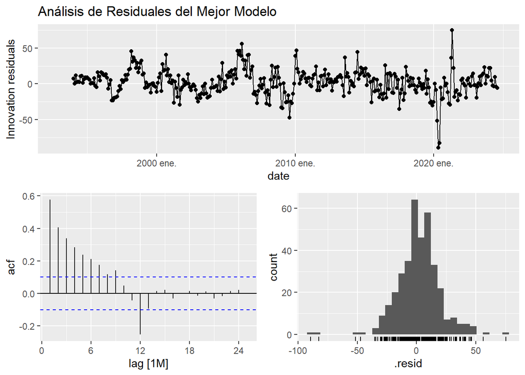

```r
fit_train |>
  select(Snaive) |>
  gg_tsresiduals() +
  labs(title = "Análisis de Residuales del Mejor Modelo")
```

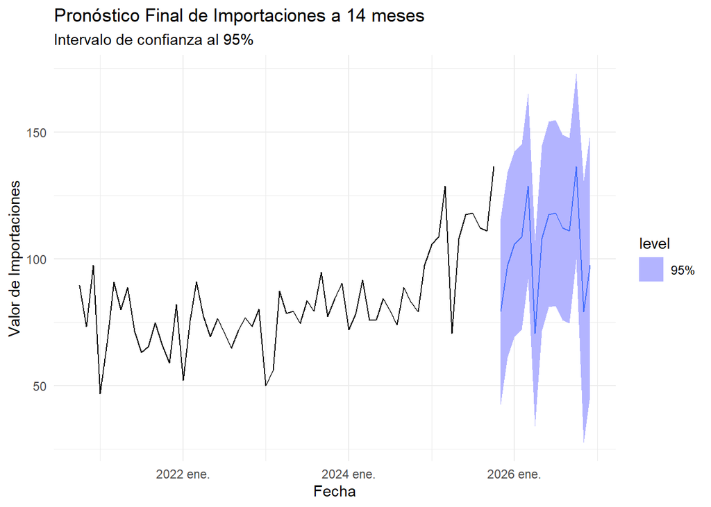

```r
fit_final <- import |>
  model(
    Snaive = SNAIVE(price)
  )

fc_final <- fit_final |>
  forecast(h = h)

fc_final |>
  autoplot(import |> filter_index("2020-10" ~ .), level = 95) +
  labs(
    title = "Pronóstico Final de Importaciones a 14 meses",
    subtitle = "Intervalo de confianza al 95%",
    y = "Valor de Importaciones",
    x = "Fecha"
  ) +
  theme_minimal()
```

```r
fit_train |>
  augment() |>
  filter(.model == "Snaive") |>
  features(.innov, ljung_box, lag = 24, dof = 0)
```

```
# A tibble: 1 × 3
  .model lb_stat lb_pvalue
  <chr>    <dbl>     <dbl>
1 Snaive    351.         0
```

### Conclusiones

Para comenzar, decidí explorar la serie de tiempo original mediante una descomposición STL. Al hacerlo, identifiqué que la serie presentaba una clara tendencia y estacionalidad, lo cual me dio una idea inicial sobre el tipo de modelo que debía implementar.

Sin embargo, al observar nuevamente la gráfica y el componente de tendencia de la descomposición STL, considero que el modelo podría optimizarse si se le incorpora un factor de tendencia. Dado que la serie de tiempo finalizaba con una tendencia bastante pronunciada, ajustar el modelo para capturar este comportamiento podría aumentar significativamente su precisión.